# Analysis of published YBX1 PARCLIP data

This document describes exploration of some PARCLIP data from a published study (PMID: 31358969). I previously processed the data into a set of annotated peaks and here I will investigate the parsed data.

## Setting up the environment

I want to set a base directory that we can use as a link to the directory where we will do most of the work. I use two directories here because the Workspace is what is pushed to GitHub and contains scripts and plot files, but the Repository is where more of the big data is stored that does not get pushed.

```r
baseWorkspace = 'C:/Users/chris/OneDrive/Documents/bccrc/projectsWorkspace/sorensenLab/relatedToYbx1'
baseRepository = 'C:/Users/chris/OneDrive/Documents/bccrc/projectsRepository/sorensenLab/relatedToYbx1'
```

Lastly, we need to call a source file that has some functions we will need. For simplicity and ease of tracking, I make a copy of this file in each directory that I will work in in order to be able to trace the exact one functions that are used, in case I change them and mistakenly don’t push it to GitHub.

```r
source(paste(baseWorkspace, '/sequencing20200527_ybx1ParclipChen/userDefinedFunctions.R', sep = ''))
```

## Data processing

First I want to look at the distribution of where the binding sites are in a consensus mRNA. Sometimes this is referred to as a metagene plot. We already have the region data as well as a ‘regionLocation’ value that we can use for this.

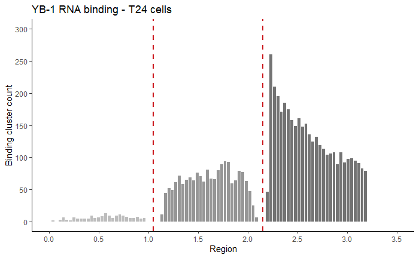

```r
##########################################################################################
parclip = readRDS(paste(baseRepository, '/sequencing20200527_ybx1ParclipChen/dataset_yb1ParclipAnnotatedPeakSet.rds', sep = ''))
#make the plot
ggplot(parclip, aes(regionLocationAdjusted, fill = region)) +
  geom_histogram(bins = 100, color = 'white', size = 0.1) +
  geom_vline(xintercept = c(1.05,2.15), linetype = 'dashed', size = 1, color = brewer.pal(9,'Reds')[7]) +
  scale_fill_manual(values = brewer.pal(9,'Greys')[c(4:6)]) +
  scale_x_continuous(limits = c(0,3.5), breaks = seq(0,3.5,0.5)) +
  scale_y_continuous(limits = c(0,300), breaks = seq(0,500,50)) +
  labs(x = 'Region', y = 'Binding cluster count', title = 'YB-1 RNA binding - T24 cells') +
  theme_classic() +
  theme(legend.position = 'none')
#write the plot to a file
ggsave(paste(baseWorkspace, '/sequencing20200527_ybx1ParclipChen/histogram_bindingSitesMetatranscript.pdf', sep = ''),
       useDingbats = FALSE,
       width = 4,
       height = 4)
```

I am also interested in the absolute number of peaks in each of the regions, regardless of their location within that region.

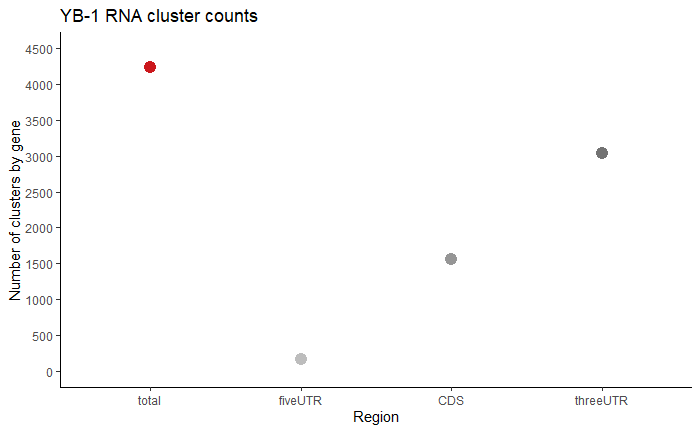

```r
#######################################################################################
parclip = readRDS(paste(baseRepository, '/sequencing20200527_ybx1ParclipChen/dataset_yb1ParclipAnnotatedPeakSet.rds', sep = ''))
##calculate the counts of individual clusters by gene in each region
##total gives the total number of individual genes, so it won't equal the sum of the individual regions
peakCounts = parclip %>%
  dplyr::select(txdbSymbol, readCountSum, region)
peakCountsSummary = tibble('region' = c('total','fiveUTR','CDS','threeUTR'),
                           'genes' = c(length(unique(peakCounts$txdbSymbol)),
                                            nrow(unique(peakCounts[peakCounts$region == 'fiveUTR', 'txdbSymbol'])),
                                            nrow(unique(peakCounts[peakCounts$region == 'CDS', 'txdbSymbol'])),
                                            nrow(unique(peakCounts[peakCounts$region == 'threeUTR', 'txdbSymbol']))))
peakCountsSummary$region = factor(peakCountsSummary$region, levels = c('total','fiveUTR','CDS','threeUTR'))
####make the plot
ggplot(peakCountsSummary, aes(region, genes)) +
  geom_point(size = 4, color = c(brewer.pal(9,'Reds')[7], brewer.pal(9,'Greys')[c(4:6)])) +
  labs(x = 'Region', y = 'Number of clusters by gene', title = 'YB-1 RNA cluster counts') +
  scale_y_continuous(limits = c(0,4500), breaks = seq(0,5000,500)) +
  theme_classic()
###write plot to a file
ggsave(paste(baseWorkspace, '/sequencing20200527_ybx1ParclipChen/scatterplot_bindingSiteAbsoluteCounts.pdf', sep = ''),
       useDingbats = FALSE,
       width = 4,
       height = 4)
```

Now I would like to see how well the clusters agree between the two replicates from the study. I already filtered the data previously such that a cluster region had to be present in both replicates (if regions were different sizes between the replicates, they were filtered to the consensus region). For this I will use the readCounts data.

```r
#######################################################################################
parclip = readRDS(paste(baseRepository, '/sequencing20200527_ybx1ParclipChen/dataset_yb1ParclipAnnotatedPeakSet.rds', sep = ''))
#for the read counts, I just log transform and then Z-score the values to make them somewhat comparable
#the read depth between the runs was quite different, so normalization here is a bit more challenging
#I am not sure if a TPM calculation is appropriate here
parclip$rep1Scaled = scale(log2(parclip$readCountRep1))
parclip$rep2Scaled = scale(log2(parclip$readCountRep2))
parclip$repScaledMean = rowMeans(parclip[,c('rep1Scaled','rep2Scaled')], na.rm = TRUE)
parclip$repDiff = parclip$rep1Scaled - parclip$rep2Scaled
#these are just some genes that I am interested in that I want to label
goi = c('PABPC1','JUN', 'HIF1A',
        'CTNNB1','ATF4','MKI67',
        'HDGF','EIF4A1','GLO1',
        'TPD52','STK26')
####set some colors and labels for the plot
cor(parclip$rep1Scaled, parclip$rep2Scaled,
    use = 'pairwise.complete.obs',
    method = 'pearson')
```

```
          [,1]
[1,] 0.6573519
```

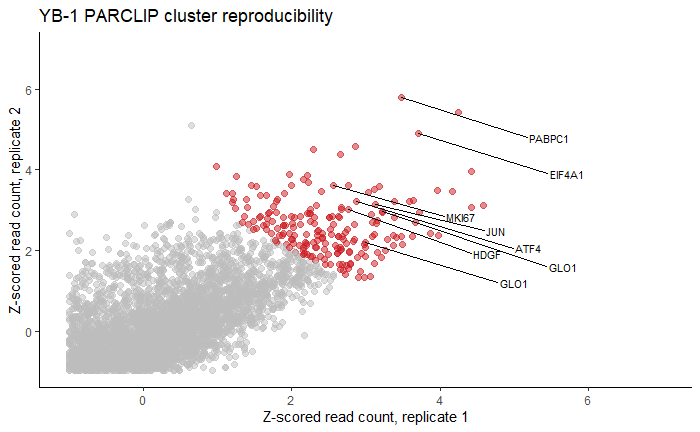

```r
parclip$pColors = ifelse(parclip$repScaledMean >= 2 & abs(parclip$repDiff) <= 4,
                         brewer.pal(9,'Reds')[7],
                         brewer.pal(9,'Greys')[4])
parclip$pText = ifelse(parclip$txdbSymbol %in% goi & parclip$repScaledMean >= 2,
                       parclip$txdbSymbol,
                       '')
#make the plot
ggplot(parclip, aes(rep1Scaled, rep2Scaled)) +
  geom_point(size = 2, color = parclip$pColors, alpha = 0.5) +
  geom_text_repel(label = parclip$pText, size = 3, segment.size = 0.2, nudge_x = 2, nudge_y = -1) +
  labs(x = 'Z-scored read count, replicate 1', y = 'Z-scored read count, replicate 2', title = 'YB-1 PARCLIP cluster reproducibility') +
  scale_y_continuous(limits = c(-1,7), breaks = seq(0,18,2)) +
  scale_x_continuous(limits = c(-1,7), breaks = seq(0,18,2)) +
  theme_classic() +
  theme(legend.position = 'none')
###write plot
ggsave(paste(baseWorkspace, '/sequencing20200527_ybx1ParclipChen/scatterplot_bindingSiteReplication.pdf', sep = ''),
       useDingbats = FALSE,
       width = 4,
       height = 4)
```

For the genes of interest I show above that all appear to be pretty reproducible and highly-bound hits, I want to show metatranscript plots.

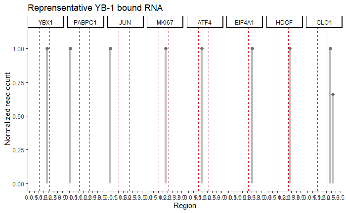

```r
####################################################################################
parclip = readRDS(paste(baseRepository, '/sequencing20200527_ybx1ParclipChen/dataset_yb1ParclipAnnotatedPeakSet.rds', sep = ''))
##genes of interest
goi = c('PABPC1','JUN','YBX1',
        'CTNNB1','ATF4','MKI67',
        'HDGF','EIF4A1','GLO1')
parclipSub = parclip[parclip$txdbSymbol %in% goi,]
parclipSub$txdbSymbol = factor(parclipSub$txdbSymbol, levels = c('YBX1','PABPC1','JUN',
                                                               'CTNNB1','MKI67','ATF4',
                                                               'EIF4A1','HDGF','GLO1'))
##normalize the values so that they are relative to the max peak
parclipNorm = tibble()
for (i in 1:length(goi)){
  gnSubset = parclipSub[parclipSub$txdbSymbol == goi[i],]
  gnSubset$normPeak = gnSubset$readCountSum / max(gnSubset$readCountSum, na.rm = TRUE)
  parclipNorm = rbind(parclipNorm, gnSubset)
}

##make a plot
ggplot(parclipNorm, aes(regionLocationAdjusted, normPeak)) +
  geom_segment(aes(x = regionLocationAdjusted, y = 0, xend = regionLocationAdjusted, yend = normPeak), color = brewer.pal(9,'Greys')[4], size = 1.5) +
  geom_point(size = 2, color = brewer.pal(9,'Greys')[6]) +
  geom_vline(xintercept = c(1.05,2.15), linetype = 'dashed', color = brewer.pal(9,'Reds')[7]) +
  scale_y_continuous(limits = c(0,1.1), breaks = seq(0,2,0.25)) +
  scale_x_continuous(limits = c(0,3.5), breaks = seq(0,3.5,0.5)) +
  labs(x = 'Region', y = 'Normalized read count', title = 'Reprensentative YB-1 bound RNA') +
  theme_classic() +
  theme(legend.position = 'none') +
  facet_wrap(~txdbSymbol, nrow = 1)
##write plot to a file
ggsave(paste(baseWorkspace, '/sequencing20200527_ybx1ParclipChen/lollipop_candidateBoundRNAs.pdf', sep = ''),
       useDingbats = FALSE,
       width = 12,
       height = 4)
```

The last two things I want to do are to get the lengths of the different regions where YBX1 has bound (e.g. if YB-1 is bound to a 5’UTR, is it a short or long one?). The other is to look at the GC content of the regions. For both of these I will need supplementary functions.

```r
########################################################################################
parclip = readRDS(paste(baseRepository, '/sequencing20200527_ybx1ParclipChen/dataset_yb1ParclipAnnotatedPeakSet.rds', sep = ''))
##in our previous analysis we made a txdb
txdbEnsembl = loadDb(file = paste(baseRepository,
                                 '/sequencing20200527_ybx1ParclipChen/TxDb.Hsapiens.ENSEMBL.hg38.v100.sqlite', sep = ''))
#####
gnLengths = geneLengthAnalysis(parclip, 1, txdbEnsembl)
```

```
Finding the longest transcript associated with each input gene in the txdb.
Core set of long transcripts assembled. Data returned.
Annotating fiveUTR hits.
Annotating the input txdb.
Filtering input txdb to keep only longest transcripts.
Returning the annotated txdb for alignment.
Annotating CDS hits.
Annotating the input txdb.
Filtering input txdb to keep only longest transcripts.
Returning the annotated txdb for alignment.
Annotating threeUTR hits.
Annotating the input txdb.
Filtering input txdb to keep only longest transcripts.
Returning the annotated txdb for alignment.
Performing final assembly.
```

```r
##output the raw data counts
table(gnLengths$status, gnLengths$region)
```

```
          fiveUTR   CDS threeUTR
  unbound   16161 15355    13550
  bound       169  1559     3036
```

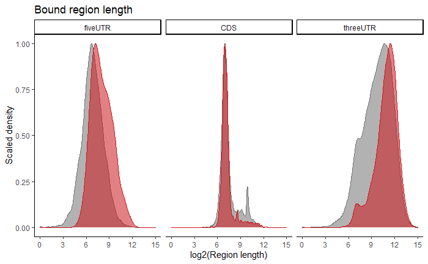

```r
####make the plot, all regions
ggplot(gnLengths, aes(log2(medianWidth), fill = status, color = status)) +
  geom_density(aes(y=..scaled..), alpha = 0.55, size = 0.5) +
  scale_fill_manual(values = c(brewer.pal(9,'Greys')[6], brewer.pal(9,'Reds')[7])) +
  scale_color_manual(values = c(brewer.pal(9,'Greys')[6], brewer.pal(9,'Reds')[7])) +
  scale_x_continuous(limits = c(0,15), breaks = seq(0,15,3)) +
  labs(x = 'log2(Region length)', y = 'Scaled density', title = 'Bound region length') +
  theme_classic() +
  theme(legend.position = 'none') +
  #theme(strip.background = element_blank(), strip.text = element_blank()) +
  facet_wrap(~region)
####save the plot
ggsave(paste(baseWorkspace, '/sequencing20200527_ybx1ParclipChen/density_boundRegionLengths.pdf', sep = ''),
       useDingbats = FALSE,
       width = 4,
       height = 4)
```

```r
########################################################################################
```

So, it seems like YBX1 binds long 5’ and 3’ UTR regions preferentially, but not real preference for CDS is shown. And now GC content for bound regions.

```r
##########################################################################################
parclip = readRDS(paste(baseRepository, '/sequencing20200527_ybx1ParclipChen/dataset_yb1ParclipAnnotatedPeakSet.rds', sep = ''))
##in our previous analysis we made a txdb
txdbEnsembl = loadDb(file = paste(baseRepository,
                                 '/sequencing20200527_ybx1ParclipChen/TxDb.Hsapiens.ENSEMBL.hg38.v100.sqlite', sep = ''))
##run the function
gnGcContent = gcContentAnalysis(parclip, 1, txdbEnsembl)
```

```
Finding the longest transcript associated with each input gene in the txdb.
Core set of long transcripts assembled. Data returned.
Annotating GC content for fiveUTR hits
Annotating the input txdb.
Filtering input txdb to keep only longest transcripts.
Returning the annotated txdb for alignment.
Annotation index created for fiveUTR
GC content for index calculated
Annotating GC content for CDS hits
Annotating the input txdb.
Filtering input txdb to keep only longest transcripts.
Returning the annotated txdb for alignment.
Annotation index created for CDS
GC content for index calculated
Annotating GC content for threeUTR hits
Annotating the input txdb.
Filtering input txdb to keep only longest transcripts.
Returning the annotated txdb for alignment.
Annotation index created for threeUTR
GC content for index calculated
Performing final assembly
```

```r
##output the raw data counts
table(gnGcContent$region, gnGcContent$status)
```

```
           unbound bound
  fiveUTR    16161   169
  CDS        15355  1559
  threeUTR   13550  3036
```

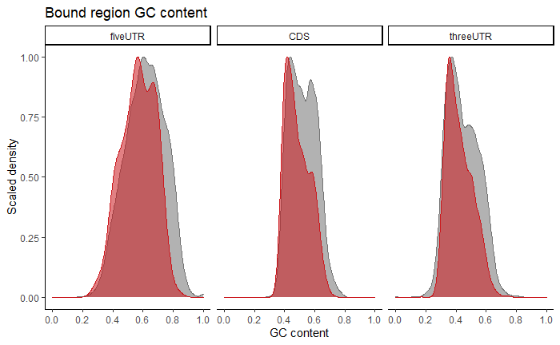

```r
####make the plot, all regions
ggplot(gnGcContent, aes(gcContent, fill = status, color = status)) +
  geom_density(aes(y=..scaled..), alpha = 0.55, size = 0.5) +
  scale_fill_manual(values = c(brewer.pal(9,'Greys')[6], brewer.pal(9,'Reds')[7])) +
  scale_color_manual(values = c(brewer.pal(9,'Greys')[6], brewer.pal(9,'Reds')[7])) +
  scale_x_continuous(limits = c(0,1), breaks = seq(0,1,0.2)) +
  labs(x = 'GC content', y = 'Scaled density', title = 'Bound region GC content') +
  theme_classic() +
  theme(legend.position = 'none') +
  facet_wrap(~region)
####save the plot
ggsave(paste(baseWorkspace, '/sequencing20200527_ybx1ParclipChen/density_boundRegionGcContent.pdf', sep = ''),
       useDingbats = FALSE,
       width = 4,
       height = 4)
```

```r
########################################################################################
```

So it seems to lean towards lower GC content, but this is pretty minimal drift. I am sure if I did a significance test here it would give me a nice p-value, but the effect size is too small for me to be interested.

In any case, we have a nice set of YBX1 bound RNAs now that we can use as a cross-reference set when parsing through expression or interaction data.

[session information not shown]